# Personal Activity Analysis Report

Hien Nguyen

Sunday, July 12, 2015

**Data** The data for this assignment can be downloaded from https://d396qusza40orc.cloudfront.net/repdata%2Fdata%2Factivity.zip  
The variables included in this dataset are:  
steps: Number of steps taking in a 5-minute interval (missing values are coded as NA)  
date: The date on which the measurement was taken in YYYY-MM-DD format  
interval: Identifier for the 5-minute interval in which measurement was taken  
The dataset is stored in a comma-separated-value (CSV) file and there are a total of 17,568 observations in this dataset.  
Load the data into an activityOrig dataset

```r
activityOrig <- read.csv("activity.csv")
```

Format the date

```r
activityOrig$date <- as.Date(activityOrig$date, "%Y-%m-%d")
```

**QUESTION 1: What is mean total number of steps taken per day?**  
Create a new dataset from activityOrig without NAs

```r
activity <- na.omit(activityOrig)
```

Calculate the total steps per day and put in the column “total”

```r
require("plyr")
sumByDate <- ddply(activity, .(date), summarise, total=sum(steps))
```

Create a histogram of the total steps and run a summary to get mean/median

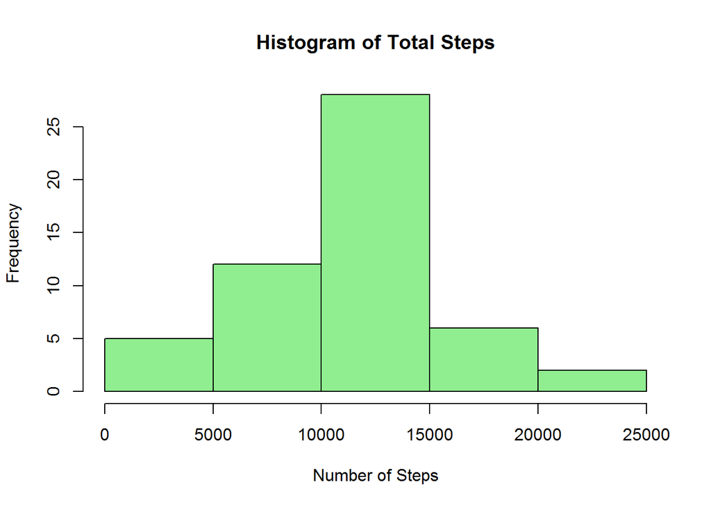

```r
mygraph <- hist(as.numeric(sumByDate$total), col="light green",main= "Histogram of Total Steps", xlab="Number of Steps", ylab="Frequency")
```

```r
summary(sumByDate)
```

```
##       date                total
##  Min.   :2012-10-02   Min.   :   41
##  1st Qu.:2012-10-16   1st Qu.: 8841
##  Median :2012-10-29   Median :10765
##  Mean   :2012-10-30   Mean   :10766
##  3rd Qu.:2012-11-16   3rd Qu.:13294
##  Max.   :2012-11-29   Max.   :21194
```

ANSWER 1 **Median :10765** **Mean :10766**

**QUESTION 2: What is the average daily activity pattern?**  
To answer this question, let’s create a subset with just 2 columns: steps and intervals

```r
stepInterval <- subset(activity, select = c(steps, interval))
```

From this subset, we are calculating the average of steps for each interval

```r
averageForEachInterval <- ddply(stepInterval, .(interval), summarise, avg=mean(steps))
```

plot the average steps per interval

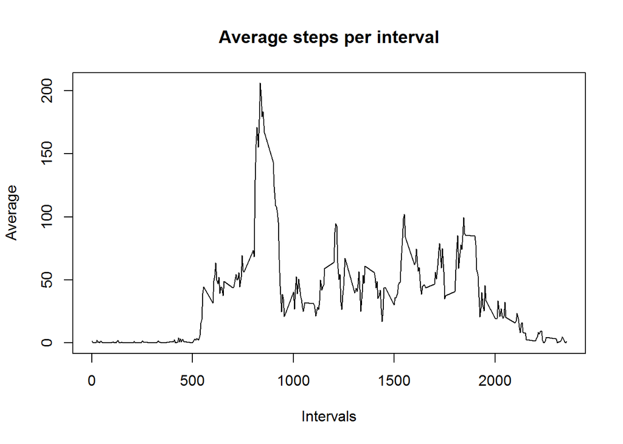

```r
mygraph2 <- with(averageForEachInterval, plot(interval, avg, main= "Average steps per interval", ylab="Average", xlab="Intervals", type="l"))
```

let’s find out what’s the max average

```r
summary(averageForEachInterval$avg)
```

```
##    Min. 1st Qu.  Median    Mean 3rd Qu.    Max.
##   0.000   2.486  34.110  37.380  52.830 206.200
```

The max is 206.170. This was a round up number  
To find which interval corresponds to this max value

```r
averageForEachInterval[as.numeric(averageForEachInterval$avg) > 206,]
```

```
##     interval      avg
## 104      835 206.1698
```

ANSWER 2: Interval 835 has the highest average of steps of 206.170

**QUESTION 3: Imputing missing values**  
1. Calculate and report the total number of missing values in the dataset (total number of rows with NAs)

```r
activityNA <- subset(activityOrig, is.na(steps))
nrow(activityNA)
```

```
## [1] 2304
```

Answer 3: 2304 rows with NA values.

2. Filling in all of the missing values in the dataset with the mean for that 5-minute interval  
a. Add the average column

```r
activityImput <- merge(activityNA, averageForEachInterval,by="interval")
```

b. Remove the NA column

```r
activityImput <- subset(activityImput, select = -c(2) )
```

c. Rename the average column to “steps”

```r
colnames(activityImput)[3] <- "steps"
```

d. Reorder the columns

```r
activityImput <- subset(activityImput, select = c(3,2,1))
```

3. Create a new dataset that is equal to the original dataset but with the missing data filled in by combining activityImput and activity.

```r
activityNew <- rbind(activity, activityImput)
```

4. Make a histogram of the total number of steps taken each day  
Calculate the total steps per day and put in the column “total”

```r
sumByDate2 <- ddply(activityNew, .(date), summarise, total=sum(steps))
```

Create a histogram of the total steps and run a summary to get mean/median

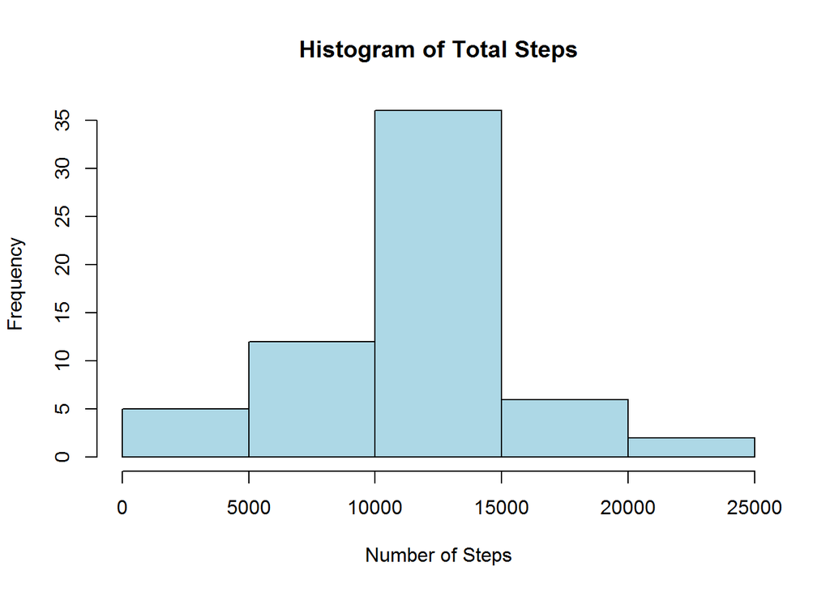

```r
mygraph2 <- hist(as.numeric(sumByDate2$total), col="light blue",main= "Histogram of Total Steps", xlab="Number of Steps", ylab="Frequency")
```

```r
summary(sumByDate2)
```

```
##       date                total
##  Min.   :2012-10-01   Min.   :   41
##  1st Qu.:2012-10-16   1st Qu.: 9819
##  Median :2012-10-31   Median :10766
##  Mean   :2012-10-31   Mean   :10766
##  3rd Qu.:2012-11-15   3rd Qu.:12811
##  Max.   :2012-11-30   Max.   :21194
```

ANSWER 3 **Median :10766** **Mean :10766**  
Do these values differ from the estimates from the first part of the assignment?  
The mean stays the same. The median is up by 1.  
What is the impact of imputing missing data on the estimates of the total daily number of steps?  
very slightly **QUESTION 4: Are there differences in activity patterns between weekdays and weekends?**  
first, add a column to store the day of the week

```r
activityNew$weekday <- weekdays(as.Date(activityNew$date))
```

then, put the Saturday and Sunday records in one table, mark them “weekend”

```r
activityWeekend <- activityNew[activityNew$weekday %in% c("Saturday", "Sunday"),]
activityWeekend$weekday <- "weekend"
```

then, put the rest of the records in one table, mark them “weekday”

```r
activityWeekday <- activityNew[activityNew$weekday %in% c("Monday", "Tuesday","Wednesday", "Thursday","Friday"),]
activityWeekday$weekday <- "weekday"
```

calculate the average for activityWeekend and activityWeekday

```r
avgPerIntervalWeekend <- ddply(activityWeekend, c("interval", "weekday"), summarise, avg=mean(steps))
avgPerIntervalWeekday <- ddply(activityWeekday, c("interval", "weekday"), summarise, avg=mean(steps))
avgPerIntervalAll <- rbind(avgPerIntervalWeekend, avgPerIntervalWeekday)
```

graph

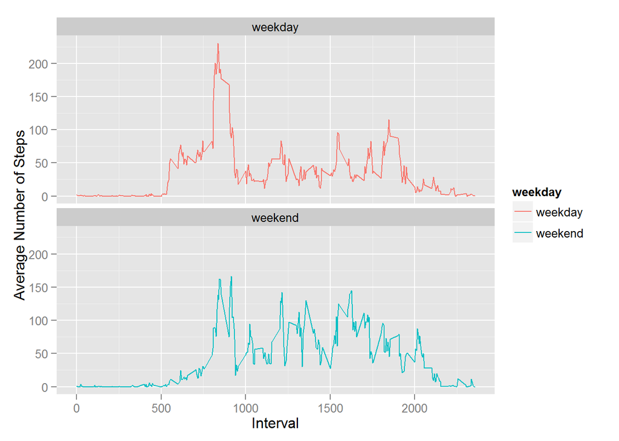

```r
require(ggplot2)
ggplot(avgPerIntervalAll, aes(interval, avg, colour = weekday)) + geom_line() + facet_grid(.~weekday) + facet_wrap(~weekday, nrow=2) +  xlab("Interval") + ylab("Average Number of Steps")
```